# What happens to the errors under fixed and random effects?

This note accompanies the second panel-data lecture. We use a simulation to distinguish a stable household component from a time-varying error and show what happens to each under FE and RE transformations.

## Two distinct problems

Consider the model

$$y_{it}=\alpha+\beta x_{it}+u_i+e_{it}.$$

Here, $u_i$ represents stable household characteristics (time-invariant unobserved heterogeneity), such as persistent preferences, while $e_{it}$ represents time-varying influences not otherwise included in the model.

**The household component $u_i$ is constant over time within each household, but differs across households.** The absence of a time subscript on $u_i$ expresses this distinction. The total error $v_{it}=u_i+e_{it}$ can still change over time.

| Problem | Consequence | Relevant response |
| --- | --- | --- |
| $u_i$ is correlated with income | Pooled OLS and conventional RE generally estimate an inconsistent slope | FE or an appropriate correlated-effects specification |
| Errors are dependent within a household | Conventional standard errors may be wrong | Household-clustered inference |

These problems are separate. Even when $u_i$ is unrelated to income, its presence creates dependence between observations from the same household under the standard error-components model. Clustering addresses uncertainty; it does not remove correlation between income and an omitted household characteristic.

## The same underlying model, different transformations

FE absorbs $\alpha+u_i$ into a household-specific intercept and permits that intercept to be related to income. Standard RE instead requires

$$E(u_i\mid x_{i1},\ldots,x_{iT})=0.$$

Both approaches still require appropriate exogeneity of the time-varying error. Random sampling of households does not, by itself, establish the RE restriction.

### Fixed effects: remove the entire household mean

The household mean equation is

$$\bar y_i=\alpha+\beta\bar x_i+u_i+\bar e_i.$$

Subtracting it from the original equation gives

$$y_{it}-\bar y_i
=\beta(x_{it}-\bar x_i)+(e_{it}-\bar e_i).$$

The stable component disappears because $u_i-u_i=0$. The transformed error is

$$v_{it}^{\mathrm{FE}}=e_{it}-\bar e_i.$$

Removing $u_i$ does not remove the remaining error or guarantee that it is unrelated to income. Nor does it make transformed observations within a household independent.

### Random effects: remove a fraction of the household mean

RE uses quasi-demeaning. For a balanced panel, define

$$\lambda=1-\sqrt{\frac{\sigma_e^2}{\sigma_e^2+T\sigma_u^2}}.$$

Subtracting $\lambda$ times the household mean equation gives

$$y_{it}-\lambda\bar y_i
=(1-\lambda)\alpha+\beta(x_{it}-\lambda\bar x_i)
+(1-\lambda)u_i+e_{it}-\lambda\bar e_i.$$

Thus the transformed error is

$$v_{it}^{\mathrm{RE}}=(1-\lambda)u_i+e_{it}-\lambda\bar e_i.$$

When $\lambda<1$, some of the household component remains. If it is correlated with income, shrinking it generally does not eliminate the resulting endogeneity. Under the standard RE covariance assumptions, the transformation is designed to account for within-household error dependence for GLS estimation; it does not require the household component itself to disappear.

|  | RE: quasi-demeaning | FE: full demeaning |
| --- | --- | --- |
| Transformation | Subtract $\lambda$ times the household mean | Subtract the entire household mean |
| Transformed error | $(1-\lambda)u_i+e_{it}-\lambda\bar e_i$ | $e_{it}-\bar e_i$ |
| Stable household component | Some remains when $\lambda<1$ | Removed |
| If $u_i$ is correlated with income | Standard RE generally remains inconsistent | FE removes this source of confounding |

In the handout’s notation, $\lambda=\theta$ and $(1-\lambda)^2=\phi^2$. The lecture uses $\omega=\phi^2$ for the weight on between sums of squares.

## A simulation: make the unobserved components visible

In the liquor data, we do not observe $u_i$ and $e_{it}$ separately. A simulation lets us construct and inspect both. We deliberately make income depend on $u_i$, so this example violates the standard RE restriction.

### 1. Generate households and repeated observations

Draw one stable component for each household, then repeat that household over three periods. Income changes with both the stable component and an independent time-varying income shock. The outcome also depends on the stable component.

```r
library(tidyverse)

set.seed(42)

# ONE stable component per household.
households <- tibble(
  hh = 1:40,
  u  = rnorm(40, mean = 0, sd = 1)
)

# THREE observations per household.
# Higher u raises both income and expenditure.
sim <- expand_grid(hh = 1:40, year = 1:3) |>
  left_join(households, by = "hh") |>
  mutate(
    x = 50 + 10 * u + rnorm(n(), sd = 4),
    e = rnorm(n(), sd = 1),
    y = 2 + 0.5 * x + u + e
  )

# u repeats within each household; x and e change over time.
sim |>
  filter(hh <= 3) |>
  select(hh, year, u, x, e, y)
```

```
# A tibble: 9 × 6
     hh  year      u     x       e     y
  <int> <int>  <dbl> <dbl>   <dbl> <dbl>
1     1     1  1.37   64.5 -0.176   35.5
2     1     2  1.37   62.3 -1.07    33.4
3     1     3  1.37   66.7  0.163   36.9
4     2     1 -0.565  41.4 -0.363   21.8
5     2     2 -0.565  38.9  0.590   21.5
6     2     3 -0.565  46.1  1.43    25.9
7     3     1  0.363  50.4 -0.993   26.6
8     3     2  0.363  59.4  0.455   32.5
9     3     3  0.363  51.9  0.0849  28.4
```

**Read the rows:** each household has the same value of $u$ in all three periods. Different households generally have different values of $u$.

The true income coefficient is $\beta=0.5$. Income is independent of the generated $e_{it}$, but related to $u_i$. The example therefore isolates stable confounding rather than time-varying endogeneity.

### 2. Apply full and partial demeaning

We set $\lambda=0.5$ to make partial removal easy to see. This is an illustrative transformation, not an estimated RE model. In an actual RE fit, the variance components determine the quasi-demeaning parameter.

```r
lambda_demo <- 0.5

sim <- sim |>
  group_by(hh) |>
  mutate(
    x_mean = mean(x),
    e_mean = mean(e),

    # FE removes the entire stable household component.
    x_fe = x - x_mean,
    u_fe = u - mean(u),
    error_fe = e - e_mean,

    # RE-style quasi-demeaning removes only a fraction of it.
    x_re = x - lambda_demo * x_mean,
    u_re = (1 - lambda_demo) * u,
    error_re = u_re + e - lambda_demo * e_mean
  ) |>
  ungroup()

sim |>
  filter(hh <= 3) |>
  select(hh, year, u, u_re, u_fe, error_re, error_fe)
```

```
# A tibble: 9 × 7
     hh  year      u   u_re  u_fe error_re error_fe
  <int> <int>  <dbl>  <dbl> <dbl>    <dbl>    <dbl>
1     1     1  1.37   0.685     0   0.691    0.186
2     1     2  1.37   0.685     0  -0.206   -0.710
3     1     3  1.37   0.685     0   1.03     0.525
4     2     1 -0.565 -0.282     0  -0.922   -0.916
5     2     2 -0.565 -0.282     0   0.0310   0.0368
6     2     3 -0.565 -0.282     0   0.873    0.879
7     3     1  0.363  0.182     0  -0.736   -0.842
8     3     2  0.363  0.182     0   0.712    0.606
9     3     3  0.363  0.182     0   0.342    0.236
```

Notice four features:

- `u` is constant within each household.
- `u_re` is smaller but still constant within that household.
- `u_fe` is zero, up to numerical precision.
- Both transformed total errors still vary over time because of $e_{it}$.

### 3. Show why the stable component is a problem

Plot household mean income against the known stable component. We use one observation per household because both quantities are household-level characteristics.

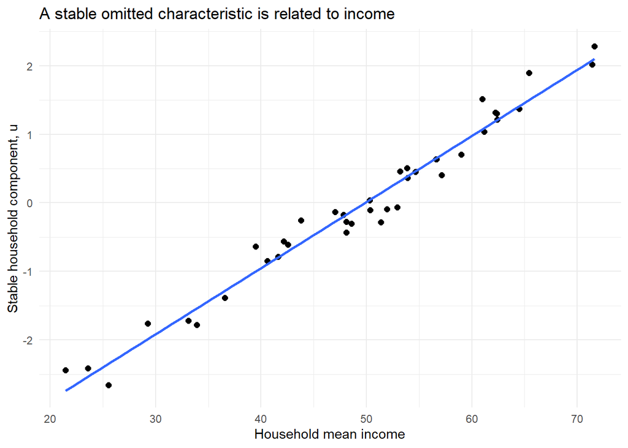

```r
sim |>
  distinct(hh, x_mean, u) |>
  ggplot(aes(x = x_mean, y = u)) +
  geom_point(size = 2) +
  geom_smooth(method = "lm", formula = y ~ x, se = FALSE) +
  labs(
    x = "Household mean income",
    y = "Stable household component, u",
    title = "A stable omitted characteristic is related to income"
  ) +
  theme_minimal()
```

Households with larger $u_i$ tend to have higher income. The association is present by construction: the income equation contains $10u_i$. A comparison between high- and low-income households therefore also compares households with different stable characteristics.

This plot is possible because the simulation reveals $u_i$. It is not a diagnostic we can reproduce directly with the real liquor data, where $u_i$ is unobserved.

### 4. Show what each transformation leaves behind

The next plot isolates the stable household component. It does **not** plot the entire transformed error.

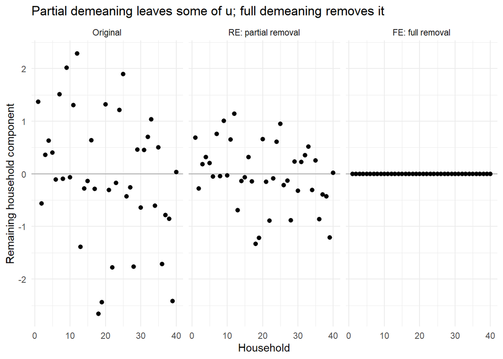

```r
sim |>
  distinct(hh, u, u_re, u_fe) |>
  pivot_longer(
    cols = c(u, u_re, u_fe),
    names_to = "transformation",
    values_to = "remaining_component"
  ) |>
  mutate(
    transformation = factor(
      transformation,
      levels = c("u", "u_re", "u_fe"),
      labels = c("Original", "RE: partial removal", "FE: full removal")
    )
  ) |>
  ggplot(aes(x = hh, y = remaining_component)) +
  geom_hline(yintercept = 0, colour = "grey65") +
  geom_point(size = 1.8) +
  facet_wrap(~ transformation, nrow = 1) +
  labs(
    x = "Household",
    y = "Remaining household component",
    title = "Partial demeaning leaves some of u; full demeaning removes it"
  ) +
  theme_minimal()
```

The panels use the same vertical scale. Partial demeaning shrinks the household component; full demeaning removes it. The household number on the horizontal axis is an identifier, not an economic variable.

## Discussion and connection to model choice

If the remaining part of $u_i$ is still related to income, have we solved the omitted-variable problem merely by making it smaller?

**Expected answer**

No. With partial demeaning, the transformed regressor can remain correlated with the transformed error. FE removes the stable additive component entirely. Standard RE instead relies on the additional restriction that the household component is unrelated to the regressor history.

Does FE eliminate every source of endogeneity?

**Expected answer**

No. If a time-varying shock affects both income and expenditure, correlation with $e_{it}$ may remain. In this simulation, $e_{it}$ was generated independently, so that additional problem is absent by construction.

Would household-clustered standard errors solve correlation between income and $u_i$?

**Expected answer**

No. Clustering changes estimated uncertainty; it does not change the slope or remove omitted-variable bias. FE and clustered inference address different problems and can be needed together.

**Connection to Mundlak:** A correlated-effects specification models the relationship between the household component and the regressor history, for example through household mean income. This is the motivation for adding `income_mean` in the lecture’s Mundlak regression. Its diagnostic examines a specified restriction; non-rejection does not prove the absence of confounding.